# Programming1FinalAssignment

```python
#required imports
import folium
import json
import math
import pandas as pd
import panel as pn
import pycountry
import yaml
from bokeh.io import output_notebook, output_file, show
from bokeh.layouts import row
from bokeh.models import FixedTicker, DatetimeTickFormatter, VBar, ColumnDataSource,FactorRange , Legend
from bokeh.plotting import figure, show
from bokeh.transform import dodge
import plotly.express as px
output_notebook()
pn.extension()
```

```python
#use configuration file
def get_config():
    with open("config.yaml", 'r') as stream:
        config = yaml.safe_load(stream)
    return config
config = get_config()
```

```python
#Load Data sources:
#1- Load Depression By Income Level
DepressionByIncomeLevelPath = (config['DepressionByIncomeLevel'])
DepressionByIncomeLevel = pd.read_csv(DepressionByIncomeLevelPath, sep='\t|,', header=0,engine='python')
try:
    print(DepressionByIncomeLevel.info())
    print(DepressionByIncomeLevel.describe())
except:
    print("DepressionByIncomeLevel not properly loaded")

#2- Load Depression By Education Level
DepressionByEducationLevelPath = (config['DepressionByEducationLevel'])
DepressionByEducationLevel = pd.read_csv(DepressionByEducationLevelPath, sep='\t|,', header=0,engine='python')
try:
    print(DepressionByEducationLevel.info())
    print(DepressionByEducationLevel.describe())
except:
    print("DepressionByEducationLevel not properly loaded")

#data Cleaning: columns name correction
DepressionByEducationLevel = DepressionByEducationLevel.rename(columns={"geo\TIME_PERIOD":"geo"})
DepressionByEducationLevel = DepressionByEducationLevel.rename(columns={"2014 ":"Value2014"})
DepressionByEducationLevel = DepressionByEducationLevel.rename(columns={"2019":"Value2019"})
DepressionByEducationLevel = DepressionByEducationLevel.rename(columns={"isced11":"EducationLevel"})

DepressionByIncomeLevel = DepressionByIncomeLevel.rename(columns={"geo\TIME_PERIOD":"geo"})
DepressionByIncomeLevel = DepressionByIncomeLevel.rename(columns={"2014 ":"Value2014"})
DepressionByIncomeLevel = DepressionByIncomeLevel.rename(columns={"2019":"Value2019"})
DepressionByIncomeLevel = DepressionByIncomeLevel.rename(columns={"quant_inc":"IncomeQualtile"})
```

```
<class 'pandas.core.frame.DataFrame'>
RangeIndex: 33372 entries, 0 to 33371
Data columns (total 9 columns):
 #   Column           Non-Null Count  Dtype
---  ------           --------------  -----
 0   freq             33372 non-null  object
 1   unit             33372 non-null  object
 2   hlth_pb          33372 non-null  object
 3   quant_inc        33372 non-null  object
 4   sex              33372 non-null  object
 5   age              33372 non-null  object
 6   geo\TIME_PERIOD  33372 non-null  object
 7   2014             33372 non-null  object
 8   2019             33372 non-null  object
dtypes: object(9)
memory usage: 2.3+ MB
None
         freq   unit hlth_pb quant_inc    sex    age geo\TIME_PERIOD  2014   \
count   33372  33372   33372     33372  33372  33372           33372  33372
unique      1      1       3         6      3     20              34    529
top         A     PC     DPR       QU1      F  TOTAL              AT     :
freq    33372  33372   11124      5562  11124   1836            1026   1782

         2019
count   33372
unique    439
top         :
freq    14364
<class 'pandas.core.frame.DataFrame'>
RangeIndex: 22275 entries, 0 to 22274
Data columns (total 9 columns):
 #   Column           Non-Null Count  Dtype
---  ------           --------------  -----
 0   freq             22275 non-null  object
 1   unit             22275 non-null  object
 2   isced11          22275 non-null  object
 3   hlth_pb          22275 non-null  object
 4   sex              22275 non-null  object
 5   age              22275 non-null  object
 6   geo\TIME_PERIOD  22275 non-null  object
 7   2014             22275 non-null  object
 8   2019             22275 non-null  object
dtypes: object(9)
memory usage: 1.5+ MB
None
         freq   unit isced11 hlth_pb    sex    age geo\TIME_PERIOD  2014   \
count   22275  22275   22275   22275  22275  22275           22275  22275
unique      1      1       4       3      3     20              34    533
top         A     PC   TOTAL     DPR      F  TOTAL              AT     :
freq    22275  22275    5589    7425   7425   1224             684   1188

         2019
count   22275
unique    382
top         :
freq     9603
```

```python
#Some Data Inspection
print("Depression By Income Level summary:")
print("shape: {}".format(DepressionByIncomeLevel.shape))
print("null records count: {}".format(DepressionByIncomeLevel.isnull().sum().sum()))
print("{} different countries/regions".format(len(DepressionByIncomeLevel.geo.unique())))
print("{} different age groups".format(len(DepressionByIncomeLevel.age.unique())))
print("{} sex types".format(DepressionByIncomeLevel.sex.unique()))
print("{} income levels ({} categories)".format(DepressionByIncomeLevel.IncomeQualtile.unique(),len(DepressionByIncomeLevel.IncomeQualtile.unique())))
print("=======================================")
print("Depression By Education Level summary:")
print("shape: {}".format(DepressionByEducationLevel.shape))
print("null records count: {}".format(DepressionByEducationLevel.isnull().sum().sum()))
print("Depression By Education Level summary:")
print("{} different countries/regions".format(len(DepressionByEducationLevel.geo.unique())))
print("{} different age groups".format(len(DepressionByEducationLevel.age.unique())))
print("{} sex types".format(DepressionByEducationLevel.sex.unique()))
print("{} education levels ({} categories)".format(DepressionByEducationLevel.EducationLevel.unique(),len(DepressionByEducationLevel.EducationLevel.unique())))
```

```
Depression By Income Level summary:
shape: (33372, 9)
null records count: 0
34 different countries/regions
20 different age groups
['F' 'M' 'T'] sex types
['QU1' 'QU2' 'QU3' 'QU4' 'QU5' 'TOTAL'] income levels (6 categories)
=======================================
Depression By Education Level summary:
shape: (22275, 9)
null records count: 0
Depression By Education Level summary:
34 different countries/regions
20 different age groups
['F' 'M' 'T'] sex types
['ED0-2' 'ED3_4' 'ED5-8' 'TOTAL'] education levels (4 categories)
```

```python
#Data Cleaning: convert values data types
DepressionByIncomeLevel["Value2014"] = pd.to_numeric(DepressionByIncomeLevel["Value2014"],errors='coerce')
DepressionByIncomeLevel["Value2019"] = pd.to_numeric(DepressionByIncomeLevel["Value2019"],errors='coerce')
DepressionByEducationLevel["Value2014"] = pd.to_numeric(DepressionByEducationLevel["Value2014"],errors='coerce')
DepressionByEducationLevel["Value2019"] = pd.to_numeric(DepressionByEducationLevel["Value2019"],errors='coerce')
#Drop null values because it is not reasonable here to interpolate or use other techniques to fill missing values
DepressionByIncomeLevel = DepressionByIncomeLevel.drop(DepressionByIncomeLevel[DepressionByIncomeLevel.Value2014.isna()].index)
DepressionByIncomeLevel = DepressionByIncomeLevel.drop(DepressionByIncomeLevel[DepressionByIncomeLevel.Value2019.isna()].index)
DepressionByEducationLevel = DepressionByEducationLevel.drop(DepressionByEducationLevel[DepressionByEducationLevel.Value2014.isna()].index)
DepressionByEducationLevel = DepressionByEducationLevel.drop(DepressionByEducationLevel[DepressionByEducationLevel.Value2019.isna()].index)
```

```python
#Add Country Name based on country code to visualize data geographically
def GetCountryNameByCode(code):
    country = pycountry.countries.get(alpha_2=code)
    if(country):
        return country.name
    elif code =="UK":
        return "United Kingdom"
    elif code =="EL":
        return "El Salvador"
    elif str.startswith(code,"EU"):
        return "European Union"
    else:
        return "NotFound"
DepressionByIncomeLevel["Country"] = [(GetCountryNameByCode(geo)) for geo in DepressionByIncomeLevel.geo]
DepressionByEducationLevel["Country"] = [(GetCountryNameByCode(geo)) for geo in DepressionByEducationLevel.geo]
```

```python
#visualize depression by income level
def BarPlotForIncomeLevel(groupColumn,year,country,func, sorter):
    avg = DepressionByIncomeLevel[(DepressionByIncomeLevel.Country == country) | (country == "All")].groupby(groupColumn).agg(average = pd.NamedAgg(column=year,aggfunc=func))
    avg.reset_index(inplace=True)
    if(sorter == "Groups(Ascending)"):
        avg.sort_values(groupColumn,inplace=True, ascending = [True])
    elif(sorter == "Groups(Descending)"):
        avg.sort_values(groupColumn,inplace=True, ascending = [False])
    elif(sorter == "Group Values(Ascending)"):
        avg.sort_values("average",inplace=True , ascending = [True])
    elif(sorter == "Group Values(Descending)"):
        avg.sort_values("average",inplace=True , ascending = [False])

    p = figure(x_range=avg[groupColumn], height=350, width=1050, title= groupColumn + " depression distribution("+ year+")" , toolbar_location=None, tools="")
    p.vbar(x=avg[groupColumn], top=avg.average, width=0.9)
    p.xgrid.grid_line_color = None
    p.y_range.start = 0
    p.xaxis.major_label_orientation = math.pi/8

    # Calculate Standard deviation when it is mean
    import numpy as np
    if(func == "mean"):
        stdDf = DepressionByIncomeLevel.groupby(groupColumn).agg(np.std)
        xs = avg[groupColumn]
        ys = avg["average"]
        yerrs = stdDf[year]
        err_xs = []
        err_ys = []
        for x, y, yerr in zip(xs, ys, yerrs):
            err_xs.append((x, x))
            err_ys.append((y - yerr, y + yerr))
        # plot them
        p.multi_line(err_xs, err_ys, color='red')
    p.yaxis.axis_label = func + " depression level (%)"
    return p

groupData = ["age","sex","Country","IncomeQualtile"]
years = ["Value2014","Value2019"]
countries = ["All"] + list(DepressionByIncomeLevel.Country.unique())

func = ["mean","max", "min"]
sorter = ["Groups(Ascending)", "Groups(Descending)", "Group Values(Ascending)","Group Values(Descending)"]
selectGroupColumn = pn.widgets.Select(name='Group By:', options=groupData)
selectYear = pn.widgets.Select(name='Show Data For Year:', options=years)
selectCountry = pn.widgets.Select(name='Show Data For Country:', options=countries)
selectFunc = pn.widgets.Select(name='Aggregation:', options=func)
selectSorter = pn.widgets.Select(name='Sort By:', options=sorter)
interact1 = pn.interact(BarPlotForIncomeLevel, groupColumn= selectGroupColumn, year = selectYear,country = selectCountry,func= selectFunc,sorter= selectSorter)
interact1
```

[interactive chart not shown]

It is quite clear that age has a direct effect on depression symptoms, also for females more depression is seen. Moreover, an increase in income level, leads to decrease in depression, so there is an indirect relation here.

```python
#visualize depression by education level
def BarPlotForEducationLevel(groupColumn,year,country, func, sorter):
    avg = DepressionByEducationLevel[(DepressionByEducationLevel.Country == country) | (country == "All")].groupby(groupColumn).agg(average = pd.NamedAgg(column=year,aggfunc=func))
    avg.reset_index(inplace=True)
    if(sorter == "Groups(Ascending)"):
        avg.sort_values(groupColumn,inplace=True, ascending = [True])
    elif(sorter == "Groups(Descending)"):
        avg.sort_values(groupColumn,inplace=True, ascending = [False])
    elif(sorter == "Group Values(Ascending)"):
        avg.sort_values("average",inplace=True , ascending = [True])
    elif(sorter == "Group Values(Descending)"):
        avg.sort_values("average",inplace=True , ascending = [False])

    p = figure(x_range=avg[groupColumn], height=350, width=1050, title= groupColumn + " depression distribution("+ year+")" , toolbar_location=None, tools="")
    p.vbar(x=avg[groupColumn], top=avg.average, width=0.9)
    p.xgrid.grid_line_color = None
    p.y_range.start = 0
    p.xaxis.major_label_orientation = math.pi/8

    # Calculate Standard deviation when it is mean
    import numpy as np
    if(func == "mean"):
        stdDf = DepressionByEducationLevel.groupby(groupColumn).agg(np.std)
        xs = avg[groupColumn]
        ys = avg["average"]
        yerrs = stdDf[year]
        err_xs = []
        err_ys = []
        for x, y, yerr in zip(xs, ys, yerrs):
            err_xs.append((x, x))
            err_ys.append((y - yerr, y + yerr))
        # plot them
        p.multi_line(err_xs, err_ys, color='red')
    p.yaxis.axis_label = func + " depression level (%)"
    return p
groupData = ["age","sex","Country","EducationLevel"]
years = ["Value2014","Value2019"]
countries = ["All"] + list(DepressionByIncomeLevel.Country.unique())
func = ["mean","max", "min"]
sorter = ["Groups(Ascending)", "Groups(Descending)", "Group Values(Ascending)","Group Values(Descending)"]
selectGroupColumn = pn.widgets.Select(name='Group By:', options=groupData)
selectYear = pn.widgets.Select(name='Show Data For Year:', options=years)
selectCountry = pn.widgets.Select(name='Show Data For Country:', options=countries)
selectFunc = pn.widgets.Select(name='Aggregation:', options=func)
selectSorter = pn.widgets.Select(name='Sort By:', options=sorter)
interact2 = pn.interact(BarPlotForEducationLevel, groupColumn= selectGroupColumn, year = selectYear,country = selectCountry,func= selectFunc,sorter= selectSorter)
interact2
```

[interactive chart not shown]

```python
#display geographical span(per country) of average depression level for both income and education levels and for both years of 2014 and 2019
avg2014IncomeLevel = DepressionByIncomeLevel.groupby("Country").agg(DPRLevel = pd.NamedAgg(column="Value2014",aggfunc="mean"))
avg2014IncomeLevel.reset_index(inplace=True)

avg2019IncomeLevel = DepressionByIncomeLevel.groupby("Country").agg(DPRLevel = pd.NamedAgg(column="Value2019",aggfunc="mean"))
avg2019IncomeLevel.reset_index(inplace=True)

avg2014EducationLevel = DepressionByEducationLevel.groupby("Country").agg(DPRLevel = pd.NamedAgg(column="Value2014",aggfunc="mean"))
avg2014EducationLevel.reset_index(inplace=True)

avg2019EducationLevel = DepressionByEducationLevel.groupby("Country").agg(DPRLevel = pd.NamedAgg(column="Value2019",aggfunc="mean"))
avg2019EducationLevel.reset_index(inplace=True)

map = folium.Map(location=[60, 10], zoom_start=3)
config = get_config()
countries_geo = (config['world-countries'])
#Average Depression Rate By Income Level Among Countries (%) in 2014
folium.Choropleth(
    geo_data=countries_geo,
    name="Average Depression Rate By Income Level Among Countries(%) in 2014",
    data=avg2014IncomeLevel,
    columns=["Country", "DPRLevel"],
    key_on="feature.properties.name",
    fill_color="YlOrBr",
    fill_opacity=0.5,
    line_opacity=.6,
    bins=[0,1,2 ,3 , 4, 5, 6, 7, 8,9,10],
    # highlight=True,
    # overlay=False,
    nan_fill_color = '#FF000000',
    legend_name="Average Depression Rate By Income Level Among Countries(%) in 2014",
).add_to(map)

#Average Depression Rate By Income Level Among Countries(%) in 2019
folium.Choropleth(
    geo_data=countries_geo,
    name="Average Depression Rate By Income Level Among Countries(%) in 2019",
    data=avg2019IncomeLevel,
    columns=["Country", "DPRLevel"],
    key_on="feature.properties.name",
    fill_color="Reds",
    fill_opacity=0.5,
    line_opacity=.6,
    bins=[0,1,2 ,3 , 4, 5, 6, 7, 8,9,10],
    # highlight=True,
    # overlay=False,
    nan_fill_color = '#FF000000',
    legend_name="Average Depression Rate By Income Level Among Countries(%) in 2019",
).add_to(map)

#Average Depression Rate By Education Level Among Countries(%) in 2014
folium.Choropleth(
    geo_data=countries_geo,
    name="Average Depression Rate By Education Level Among Countries(%) in 2014",
    data=avg2014EducationLevel,
    columns=["Country", "DPRLevel"],
    key_on="feature.properties.name",
    fill_color="Greens",
    fill_opacity=0.5,
    line_opacity=.6,
    bins=[0,1,2 ,3 , 4, 5, 6, 7, 8,9,10],
    # highlight=True,
    # overlay=False,
    nan_fill_color = '#FF000000',
    legend_name="Average Depression Rate By Education Level Among Countries(%) in 2014",
).add_to(map)

#Average Depression Rate By Education Level Among Countries(%) in 2019
folium.Choropleth(
    geo_data=countries_geo,
    name="Average Depression Rate By Education Level Among Countries(%) in 2019",
    data=avg2019EducationLevel,
    columns=["Country", "DPRLevel"],
    key_on="feature.properties.name",
    fill_color="Purples",
    #"codes": ["viridis","Spectral", "RdYlGn", "PuBu", "Accent", "OrRd", "Set1", "Set2", "Set3", "BuPu", "Dark2", "RdBu", "Oranges", "BuGn", "PiYG", "YlOrBr", "YlGn", "Pastel2", "RdPu", "Greens", "PRGn", "YlGnBu", "RdYlBu", "Paired", "BrBG", "Purples", "Reds", "Pastel1", "GnBu", "Greys", "RdGy", "YlOrRd", "PuOr", "PuRd", "Blues", "PuBuGn"]}
    fill_opacity=0.5,
    line_opacity=.6,
    bins=[0,1,2 ,3 , 4, 5, 6, 7, 8,9,10],
    # highlight=True,
    # overlay=False,
    nan_fill_color = '#FF000000',
    legend_name="Average Depression Rate By Education Level Among Countries(%) in 2019",

).add_to(map)

folium.LayerControl().add_to(map)
map
```

Make this Notebook Trusted to load map: File -> Trust Notebook

[interactive chart not shown]

So far we individually looked at both depression by income and education level, and groupped the data based on age, sex, country, income and education levels and sorted them based on these groups and their values, which show that both education and income has a direct effect on depression level.

Now we combine two datasets to answer the final question: is there a relation between education and income for a certain level of depression? Depression levels are expressed as percentage values, and to combile two datasets we convert depression values to depression categoris, then based on depression categories, we join two datasets to get a unique dataset (for each year, i.e. 2014 and 2019) which for a given depression contains education and income levels

```python
#convert income quantile and education level to int values to be able to make some comparisons
def getQuantileNo(quant_inc):
    if(quant_inc =="QU1"):
        return 1
    elif(quant_inc =="QU2"):
        return 2
    elif(quant_inc =="QU3"):
        return 3
    elif(quant_inc =="QU4"):
        return 4
    elif(quant_inc =="QU5"):
        return 5
    elif(quant_inc =="TOTAL"):
        return 0
def getEducationLevelNo(level):
    if(level =="ED0-2"):
        return 1
    elif(level =="ED3_4"):
        return 2
    elif(level =="ED5-8"):
        return 3
    elif(level =="TOTAL"):
        return 0
DepressionByIncomeLevel["IncomeQuantileInt"] = [getQuantileNo(quant_inc)for quant_inc in DepressionByIncomeLevel.IncomeQualtile]
DepressionByIncomeLevel['IncomeQuantileInt'] = pd.to_numeric(DepressionByIncomeLevel['IncomeQuantileInt'], errors='coerce')
DepressionByEducationLevel["EducationLevelInt"] = [getEducationLevelNo(educationLevel)for educationLevel in DepressionByEducationLevel.EducationLevel]
DepressionByEducationLevel['EducationLevelInt'] = pd.to_numeric(DepressionByEducationLevel['EducationLevelInt'], errors='coerce')
```

```python
#round depression percentage values to make categories to be able to join two datasets based on depression categories ...
DepressionByIncomeLevel["DepressionCategory2014"] = DepressionByIncomeLevel.Value2014//1
DepressionByIncomeLevel["DepressionCategory2019"] = DepressionByIncomeLevel.Value2019//1
DepressionByEducationLevel["DepressionCategory2014"] = DepressionByEducationLevel.Value2014//1
DepressionByEducationLevel["DepressionCategory2019"] = DepressionByEducationLevel.Value2019//1

#Now get a unique dataset for each year(2014 and 2019) having education and income leves for a given depression category:
#For 2014
Depression2014 = pd.merge(DepressionByIncomeLevel, DepressionByEducationLevel, on=["age","sex","Country","DepressionCategory2014"] )
Depression2014 = Depression2014[["IncomeQuantileInt","EducationLevelInt","age","sex","Country","DepressionCategory2014"]]
#For 2019
Depression2019 = pd.merge(DepressionByIncomeLevel, DepressionByEducationLevel, on=["age","sex","Country","DepressionCategory2019"] )
Depression2019 = Depression2019[["IncomeQuantileInt","EducationLevelInt","age","sex","Country","DepressionCategory2019"]]

#Remove totals(rows considering all income quantiles or all educatin levels)
Depression2014 = Depression2014.drop(Depression2014[Depression2014.IncomeQuantileInt == 0].index)
Depression2014 = Depression2014.drop(Depression2014[Depression2014.EducationLevelInt == 0].index)
Depression2019 = Depression2019.drop(Depression2019[Depression2019.IncomeQuantileInt == 0].index)
Depression2019 = Depression2019.drop(Depression2019[Depression2019.EducationLevelInt == 0].index)
```

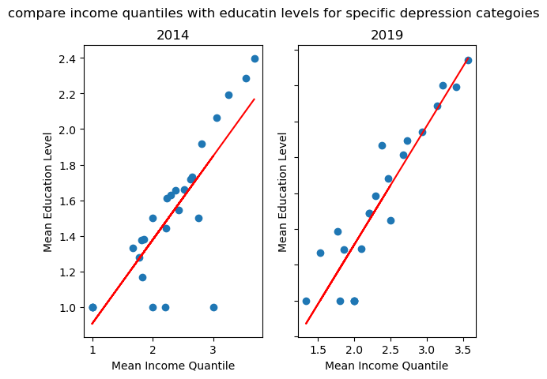

```python
import matplotlib.pyplot as plt
import numpy as np
Depression2014Avg = Depression2014.groupby(['DepressionCategory2014']).mean()
Depression2014Avg.reset_index(inplace=True)
x1 = Depression2014Avg.IncomeQuantileInt
y1 = Depression2014Avg.EducationLevelInt
fig, axs = plt.subplots(1,2)
fig.suptitle('compare income quantiles with educatin levels for specific depression categoies')
axs[0].scatter(x1,y1)
axs[0].title.set_text("2014")
# axs[0].xlabel("Mean Income quantile")
# axs[0].ylabel("Mean Education Level")
m1, b1 = np.polyfit(x1, y1, 1)
axs[0].plot(x1, m1*x1+b1,color='red')
axs[0].set(xlabel='Mean Income Quantile', ylabel='Mean Education Level')
axs[0].label_outer()

Depression2019Avg = Depression2019.groupby(['DepressionCategory2019']).mean()
Depression2019Avg.reset_index(inplace=True)
x2 = Depression2019Avg.IncomeQuantileInt
y2 = Depression2019Avg.EducationLevelInt
axs[1].scatter(x2,y2)
# axs[0].title("compare income quantiles with educatin levels for a specific depression category - 2014")
# axs[0].xlabel("Mean Income quantile")
# axs[0].ylabel("Mean Education Level")
m2, b2 = np.polyfit(x2, y2, 1)
axs[1].plot(x2, m2*x2+b2,color='red')
axs[1].label_outer()
axs[1].set(xlabel='Mean Income Quantile', ylabel='Mean Education Level')
axs[1].title.set_text("2019")

plt.show()
```

As explained before, based on same depression symptom values, we got education and income levels for both year 2014 and 2019. the scatter plots and the regression line show that for a given depression symptom level there are direct relation between income and education levels.

It is not clear in above scatter plots how depression changed by increase in both income and education levels. Below 3D plots show how depression changed by increase in both in income and education for both of the years. For both plots (2014 and 2019) we see a direct relation beteen the 3 parameters: education level, income level and depression symptoms

```python
#2014
fig = px.scatter_3d(Depression2014Avg, x='IncomeQuantileInt', y='EducationLevelInt', z='DepressionCategory2014',size=Depression2014Avg.DepressionCategory2014)
fig.show()
```

[interactive chart not shown]

```python
#2019
fig = px.scatter_3d(Depression2019Avg, x='IncomeQuantileInt', y='EducationLevelInt', z='DepressionCategory2019',size=Depression2019Avg.DepressionCategory2019)
fig.show()
```

[interactive chart not shown]